# Untitled

# 8.3.3 Bagging and Random Forests

Let’s see if we can improve on this result using **bagging** and **random forests**. The exact results obtained in this section may depend on the version of `R` and the version of the `randomForest` package installed on your computer, so don’t stress out if you don’t match up exactly with the book. Recall that **bagging** is simply a special case of a **random forest** with $m = p$. Therefore, the `randomForest()` function can be used to perform both random forests and bagging. Let’s start with bagging:

```r
library(randomForest)
set.seed(1)
bag_boston = randomForest(medv~.,
                          data = boston_train,
                          mtry = 13,
                          importance = TRUE)
bag_boston
```

```
##
## Call:
##  randomForest(formula = medv ~ ., data = boston_train, mtry = 13,      importance = TRUE)
##                Type of random forest: regression
##                      Number of trees: 500
## No. of variables tried at each split: 13
##
##           Mean of squared residuals: 11.39601
##                     % Var explained: 85.17
```

The argument `mtry = 13` indicates that all 13 predictors should be considered for each split of the tree – in other words, that bagging should be done. How well does this bagged model perform on the test set?

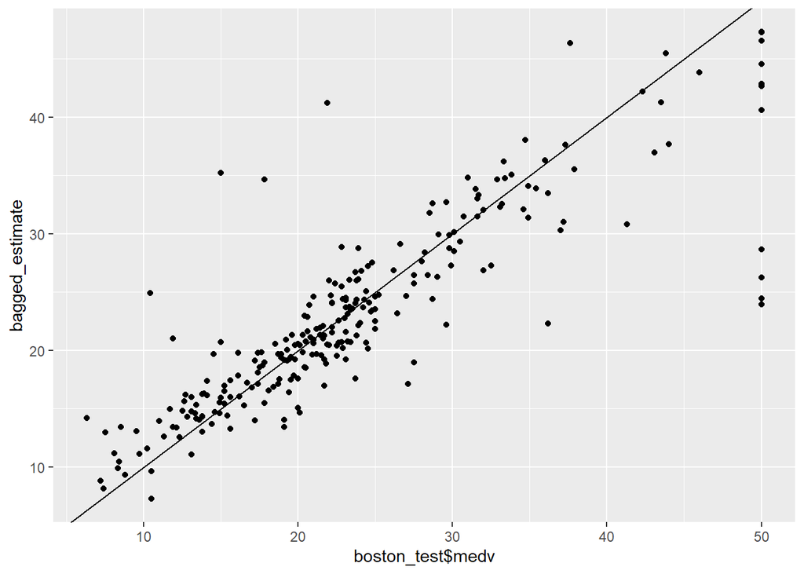

```r
bagged_estimate = predict(bag_boston,
                          newdata = boston_test)

ggplot() +
    geom_point(aes(x = boston_test$medv, y = bagged_estimate)) +
    geom_abline()
```

```r
bag_boston_25_trees = randomForest(medv~., data =  boston_train, mtry = 13, ntree = 25)
bagged_estimate_25_trees = predict(bag_boston_25_trees, newdata = boston_test)
mean((bagged_estimate_25_trees - boston_test$medv)^2)
```

```
## [1] 23.66716
```

```r
set.seed(1)
rf_boston = randomForest(medv~.,
                         data = boston_train,
                         mtry = 6,
                         importance = TRUE)

random_forest_estimate = predict(rf_boston,
                                 newdata = boston_test)

mean((random_forest_estimate - boston_test$medv)^2)
```

```
## [1] 19.62021
```

The test set MSE is even lower; this indicates that random forests yielded an improvement over bagging in this case.

Using the `importance()` function, we can view the importance of each variable:

```r
importance(rf_boston)
```

```
##           %IncMSE IncNodePurity
## crim    16.697017    1076.08786
## zn       3.625784      88.35342
## indus    4.968621     609.53356
## chas     1.061432      52.21793
## nox     13.518179     709.87339
## rm      32.343305    7857.65451
## age     13.272498     612.21424
## dis      9.032477     714.94674
## rad      2.878434      95.80598
## tax      9.118801     364.92479
## ptratio  8.467062     823.93341
## black    7.579482     275.62272
## lstat   27.129817    6027.63740
```

Two measures of variable importance are reported. The former is based upon the **mean decrease of accuracy in predictions** on the out-of-bag samples when a given variable is excluded from the model. The latter is a measure of the **total decrease in node impurity** that results from splits over that variable, averaged over all tree_ In the case of regression trees, the node impurity is measured by the training RSS, and for classification trees by the deviance. Plots of these importance measures can be produced using the `varImpPlot()` function:

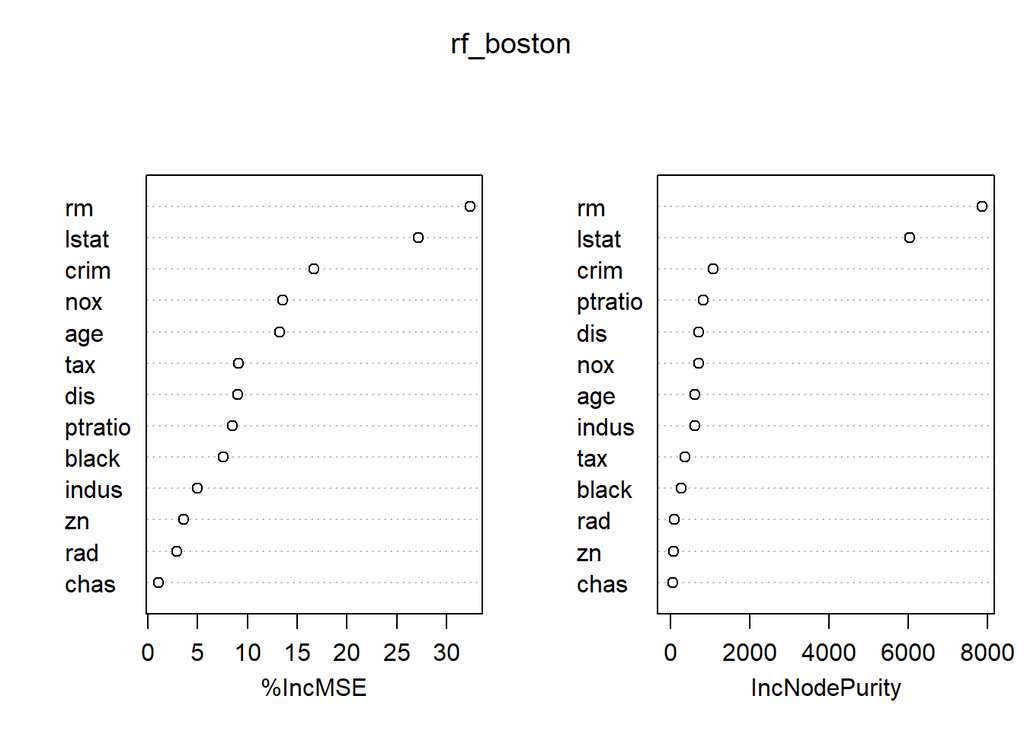

```r
varImpPlot(rf_boston)
```

The results indicate that across all of the trees considered in the random forest, the wealth level of the community (`lstat`) and the house size (`rm`) are by far the two most important variables.

# 8.3.4 Boosting

Now we’ll use the `gbm` package, and within it the `gbm()` function, to fit **boosted regression trees** to the `Boston` data set. We run `gbm()` with the option `distribution="gaussian"` since this is a regression problem; if it were a binary classification problem, we would use `distribution="bernoulli"`. The argument `n.trees=5000` indicates that we want 5000 trees, and the option `interaction.depth=4` limits the depth of each tree:

````
```r
  library(gbm)
```

```
## Loaded gbm 2.1.8
```

```r
  set.seed(1)
  boost_boston = gbm(medv~.,
                 data = boston_train,
                 distribution = "gaussian",
                 n.trees = 5000,
                 interaction.depth = 4)
```
````

The `summary()` function produces a relative influence plot and also outputs the relative influence statistics:

[output not shown]

We see that `lstat` and `rm` are again the most important variables by far. We can also produce partial dependence plots for these two variables. These plots illustrate the marginal effect of the selected variables on the response after integrating out the other variables. In this case, as we might expect, median house prices are increasing with `rm` and decreasing with `lstat`:

[output not shown]

Now let’s use the boosted model to predict `medv` on the test set:

```r
boost_estimate = predict(boost_boston,
                         newdata = boston_test,
                         n.trees = 5000)

mean((boost_estimate - boston_test$medv)^2)
```

```
## [1] 18.84709
```

```r
boost_boston2 = gbm(medv~., data = boston_train,
                    distribution = "gaussian",
                    n.trees = 5000,
                    interaction.depth = 4,
                    shrinkage = 0.01,
                    verbose = F)

boost_estimate2 = predict(boost_boston2, newdata = boston_test, n.trees = 5000)
mean((boost_estimate2-boston_test$medv)^2)
```

```
## [1] 17.94439
```

To get credit for this lab, post your responses to the following questions: - What’s one real-world scenario where you might try using Bagging? - What’s one real-world scenario where you might try using Random Forests? - What’s one real-world scenario where you might try using Boosting?

[output not shown]